# The FIFA World Cup: Executive Summary

Author

Sonia Bhatia

Published

December 6, 2023

**Github Repo Link**

My github link is below.

https://github.com/stat301-1-2023-fall/final-project-1-soniab101

## Introduction

Data on the FIFA World Cup holds a great amount of interesting information related to the global popularity of soccer, the performance of the teams, and the changes in the structure of the tournament over time. I wanted to analyze these aspects of the data, focusing on what factors influence attendance of matches and of the World Cup as a whole, and analyzing the performance of different teams over time.

## Attendance

I also learned a lot about the overall total attendance of World Cups through my analysis. Looking at the trend in total World Cup attendance over the years (from 1930 - 2014), I saw that the overall attendance has increased greatly over the years from around 600,000 people in 1930 to 3,300,000 people in 2014. This is definitely attributed to more teams participating in the tournament throughout the years resulting in a large increase in the number of matches played. Additionally, the world population has greatly increased since the time of the first World Cup. Still, however, this information about the trend in overall attendance demonstrates the great increase in attention and popularity the World Cup has gained over the years, and the steep peaks in attendance produce thought provoking questions regarding what could have caused them. I was able to find some answers to my questions regarding how the World Cup attendance varies based on which country it is hosted in. For example, I concluded that the World Cup hosted in 1994 in USA had the highest total attendance overall, with about 3.6 million attendees. I found this surprising because I did not realize that soccer was so popular of a sport in America. Brazil and Germany had the second and third highest attendances, respectively, which was less surprising to me since these countries are well known for having very strong soccer teams. A next step could be investigating whether the match attendance has a positive relationship with the number of goals scored by a team since having a large supportive crowd can be a source of motivation for the players to perform better.

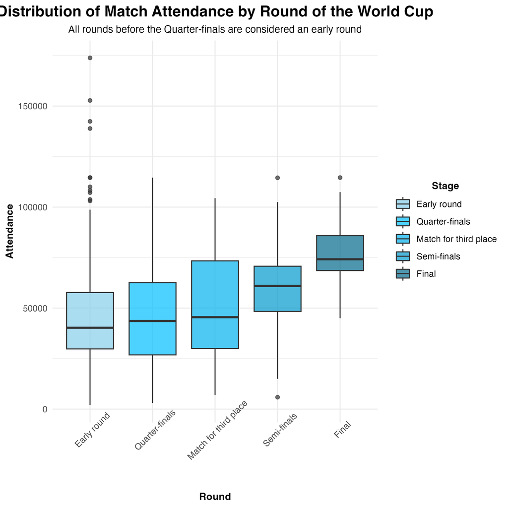

Match Attendance vs World Cup Round

## Performance of Teams

Since the first World Cup in 1930, the total number of goals scored in the World Cup has experienced an upward trend over time. This can definitely be attributed to the fact that the number of matches played in the World Cup has increased over time, but may also be attributed to improvements in the different teams’ performances. It was interesting to look at the variability in the total goals scored of the five teams that hold the most World Cup titles. Looking at the six recent World Cups, I was able to see how Brazil scored the most goals in the 1994, 1998, and 2002 World Cups, while Germany scored the most in the 2006,2010, and 2014 World Cups. This is consistent with the fact that Brazil holds the most titles (5) and Germany holds the second most of (4). It was interesting to see that Italy has not performed as well in the more recent 2010 and 2014 World Cups since they also hold the second most World Cup titles. An interesting next step to take would be to investigate whether there is a relationship between hosting the World Cup and how many goals that team scores since the host country often has the crowd on their side and very large match attendances.

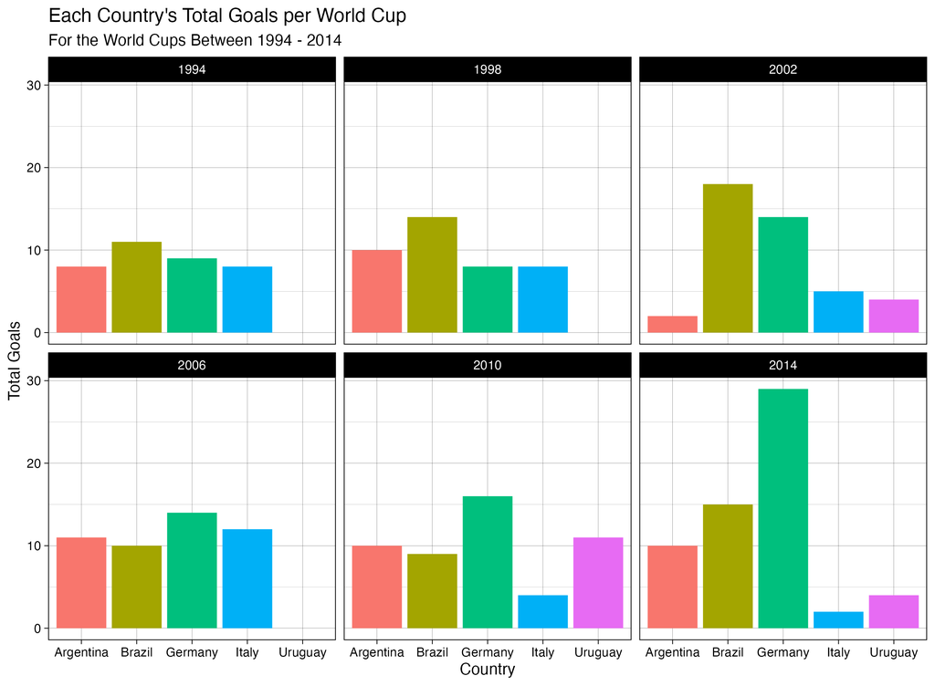

Top Five Teams’ Total Goals for the Recent World Cups